# PRINCIPAL COMPONENT ANALYSIS OF CANPATH+1KG DATA

BRENDAN NEWTON

We performed PCA on pruned genotype data for 12,000+ self-reported white individuals from the Canadian Partnership for Tomorrow’s Health (CanPath) using PLINKv1.9b (https://www.cog-genomics.org/plink/1.9/). This generates tables of eigenvalues and eigenvectors, the former being useful for describing the proportion of variance explained by each PC. Ancestry data from the 1000 Genomes Project (1KG) phase 3 was appended to the CanPath phenotype file and included in the PCA plots to identify whether the self-reported white individuals from the CanPath data would cluster with European individuals from 1KG. Individuals beyond a certain Euclidean distance from the centroid were considered outliers and removed before conducting another PCA on the pruned dataset. The first 10 PCs from the second PCA were then incorporated into the phenotype file to covary for population substructure in our genome-wide association.

Here we merge our PCA results and phenotype file for plotting:

```r
# Load packages
library(tidyverse)

# Import PCA output
PCA_RESULTS <- read.table("1KG_CanPath_merged_PCA_PCs.eigenvec", header = FALSE)
colnames(PCA_RESULTS) <- c("FID", "ID", paste("PC", 1:20, sep=""))
PCA_RESULTS$FID <- NULL

# Create new phenotype dataframe
PHENOTYPE <- read.csv("PCA_4MODELS.csv", header = TRUE)

# Merge PCA results with phenotype file
PCA_PHENOTYPE_MERGED <- merge(PHENOTYPE, PCA_RESULTS, by = "ID")
head(PCA_PHENOTYPE_MERGED[1:12])
```

```
##         ID ADM_STUDY_DATASET DATASET ANCESTRY_POP ANCESTRY_SUPERPOP M1 M2 M3 M4        PC1          PC2          PC3
## 1 11100004              CAG3 CANPATH                            EUR  2  2 NA NA 0.00122914 -8.42838e-05 -0.000639720
## 2 11100015              CAG3 CANPATH                            EUR  2  2 NA NA 0.00182406 -1.27101e-03 -0.005869590
## 3 11100016              CAG2 CANPATH                            EUR  1 NA  1 NA 0.00163399 -8.67315e-04 -0.000635513
## 4 11100021              CAG3 CANPATH                            EUR  1  1  1  1 0.00132193 -7.48584e-04  0.000951973
## 5 11100022              CAG2 CANPATH                            EUR  1 NA  1 NA 0.00152363 -1.00798e-03 -0.001161220
## 6 11100030              CAG3 CANPATH                            EUR NA NA  2  2 0.00159927 -1.32319e-03  0.000165992
```

Here we read in our table of eigenvalues and create data for plotting proportion of variance explained:

```r
# Reading in eigenvalues
eigenvalues <- read.table("1KG_CanPath_merged_PCA_PCs.eigenval")
colnames(eigenvalues) <- "evals"

# Calculate variance explained for all 20 PCs
eval_df <- data.frame(pc = sub("^", "PC", 1:nrow(eigenvalues)),
  evals = eigenvalues,
  var_exp = (eigenvalues$evals/sum(eigenvalues$evals))*100)
eval_df <- eval_df %>% mutate(cum_var = cumsum(var_exp),
                   var_exp_rounded = round(var_exp, 2),
                   cum_var_rounded = round(cum_var, 2),
                   var_exp_percent = sub("$", "%", var_exp_rounded),
                   cum_var_percent = sub("$", "%", cum_var_rounded))

head(eval_df)
```

```
##    pc    evals   var_exp  cum_var var_exp_rounded cum_var_rounded var_exp_percent cum_var_percent
## 1 PC1 477.5590 47.326586 47.32659           47.33           47.33          47.33%          47.33%
## 2 PC2 228.3020 22.624962 69.95155           22.62           69.95          22.62%          69.95%
## 3 PC3  42.7572  4.237282 74.18883            4.24           74.19           4.24%          74.19%
## 4 PC4  38.6608  3.831325 78.02016            3.83           78.02           3.83%          78.02%
## 5 PC5  34.5447  3.423415 81.44357            3.42           81.44           3.42%          81.44%
## 6 PC6  27.8508  2.760043 84.20361            2.76           84.20           2.76%           84.2%
```

We also need to calculate the mean and SD of **only the EUR individuals from 1KG**, as well as creating a subset of our data with only PCA data points. This is important for removing outliers, as will be explained later.

```r
# Creating means, SDs, and a dataframe with only IDs (end) and PCA points
PCA_MEANS <- sapply(PCA_PHENOTYPE_MERGED[PCA_PHENOTYPE_MERGED$ANCESTRY_SUPERPOP=="EUR" & PCA_PHENOTYPE_MERGED$DATASET=="KG",-(1:9)], mean)
PCA_SD <- sapply(PCA_PHENOTYPE_MERGED[PCA_PHENOTYPE_MERGED$ANCESTRY_SUPERPOP=="EUR" & PCA_PHENOTYPE_MERGED$DATASET=="KG",-(1:9)], sd)
PCA_POSITIONS <- PCA_PHENOTYPE_MERGED[,-(2:9)]
PCA_POSITIONS <- PCA_POSITIONS %>% relocate(ID, .after = PC20)
```

See below the results of PCA and associated plots:

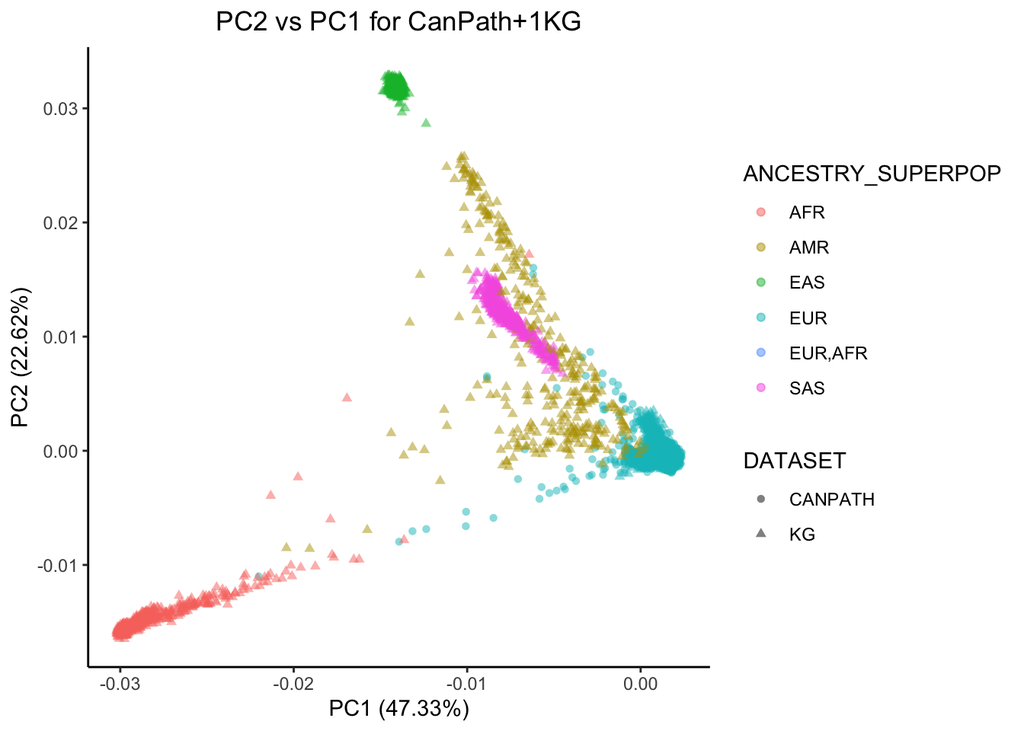

```r
#PC2-PC1
ggplot(PCA_PHENOTYPE_MERGED) +
  geom_point(aes(x=PC1, y=PC2, color=ANCESTRY_SUPERPOP, shape=DATASET), alpha=0.5) +
  labs(title = "PC2 vs PC1 for CanPath+1KG", x=sub("@", eval_df$var_exp_percent[1], "PC1 (@)"), y=sub("@", eval_df$var_exp_percent[2], "PC2 (@)")) +
  theme_classic() +
  theme(plot.title = element_text(hjust = 0.5))
```

Note that the white individuals from CanPath cluster with European individuals from 1KG, as expected.

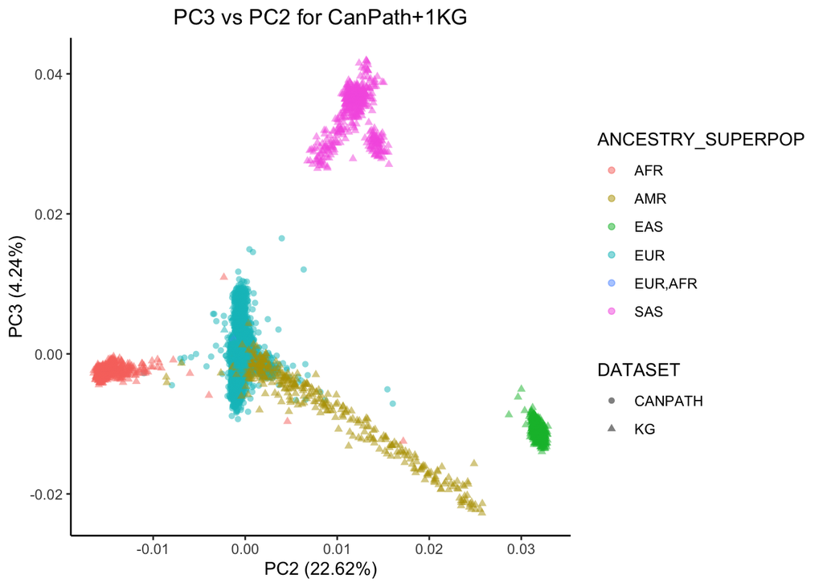

```r
#PC3-PC2
ggplot(PCA_PHENOTYPE_MERGED) +
  geom_point(aes(x=PC2, y=PC3, color=ANCESTRY_SUPERPOP, shape=DATASET), alpha=0.5) +
  labs(title = "PC3 vs PC2 for CanPath+1KG", x=sub("@", eval_df$var_exp_percent[2], "PC2 (@)"), y=sub("@", eval_df$var_exp_percent[3], "PC3 (@)")) +
  theme_classic() +
  theme(plot.title = element_text(hjust = 0.5))
```

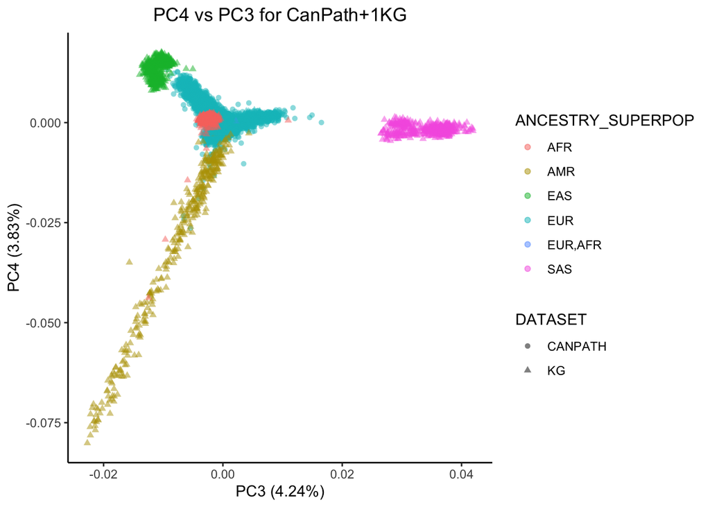

```r
#PC4-PC3
ggplot(PCA_PHENOTYPE_MERGED) +
  geom_point(aes(x=PC3, y=PC4, color=ANCESTRY_SUPERPOP, shape=DATASET), alpha=0.5) +
  labs(title = "PC4 vs PC3 for CanPath+1KG", x=sub("@", eval_df$var_exp_percent[3], "PC3 (@)"), y=sub("@", eval_df$var_exp_percent[4], "PC4 (@)")) +
  theme_classic() +
  theme(plot.title = element_text(hjust = 0.5))
```

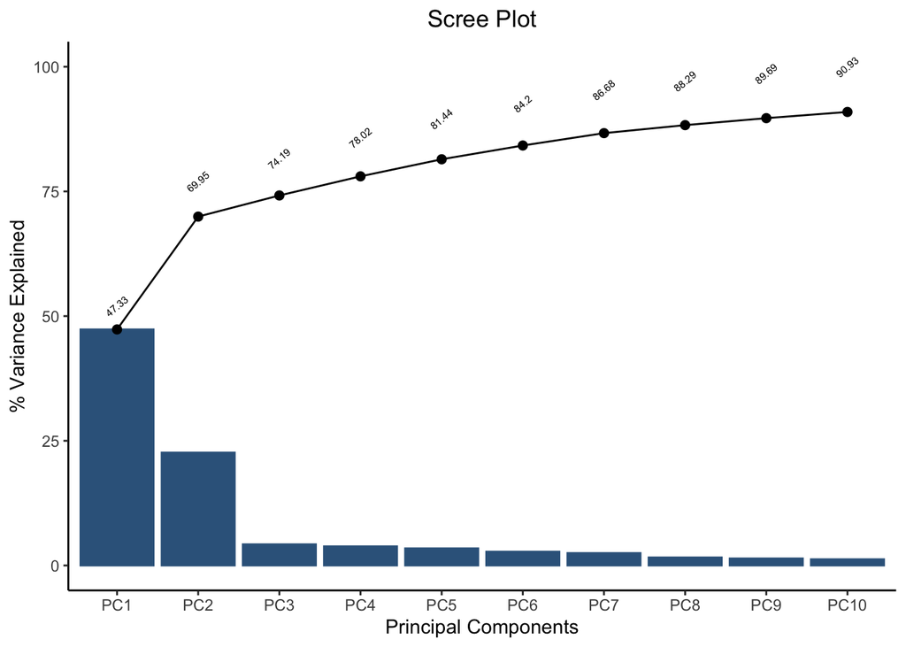

```r
# Scree Plot
ggplot(eval_df[1:10,]) +
  geom_col(aes(x = reorder(pc, -var_exp, sum), y = var_exp), colour = 'steelblue4', fill = 'steelblue4') +
             geom_line(data = eval_df[1:10,], aes(x = reorder(pc, -cum_var, sum), y = cum_var), group = 1) +
             geom_point(data = eval_df[1:10,], aes(x = pc, y = cum_var), size = 2) +
             labs(title = "Scree Plot", x = "Principal Components", y = "% Variance Explained") +
  geom_text(aes(x = pc, y = cum_var, label = cum_var_rounded, group = pc), size = 2, position = position_stack(vjust = 1.1), angle = 40) +
  theme_classic() +
  theme(plot.title = element_text(hjust = 0.5))
```

This plot shows the proportion of variance explained by each PC as well as the cumulative variance explained by the first 10 PCs.

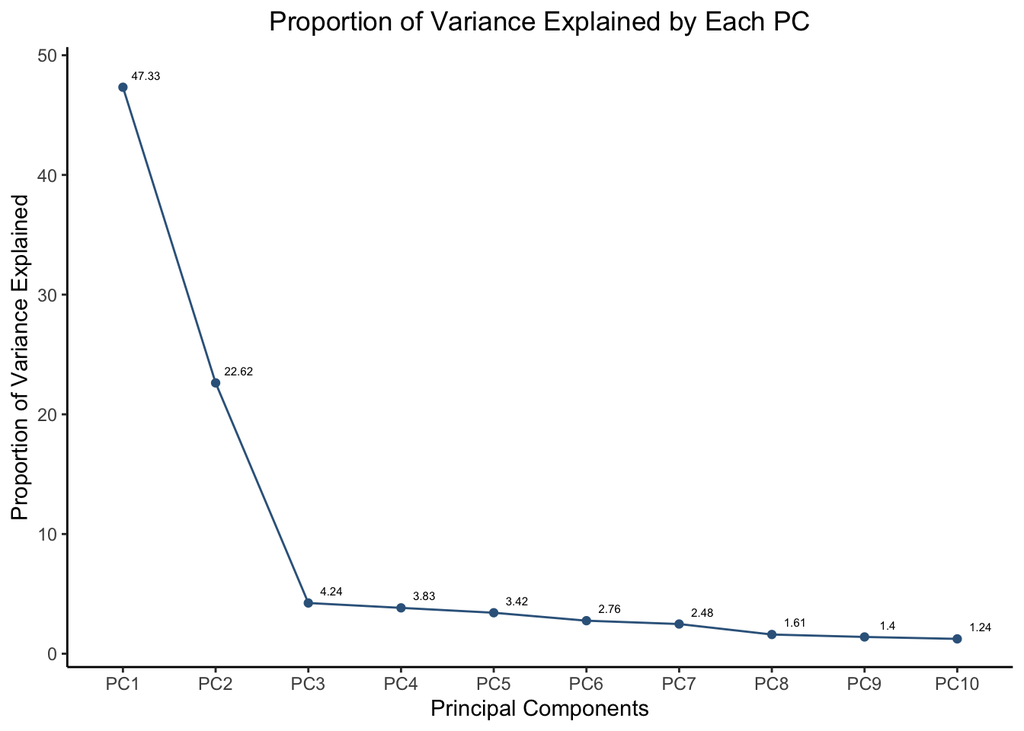

```r
# Variance Explained Plot
ggplot(eval_df[1:10,]) +
  geom_point(data = eval_df[1:10,], aes(x = reorder(pc, -var_exp, sum), y = var_exp, group = pc), color='steelblue4') +
  geom_line(data = eval_df[1:10,], aes(x = reorder(pc, -var_exp, sum), y = var_exp, group = 1), color='steelblue4') +
  labs(title = "Proportion of Variance Explained by Each PC", x = 'Principal Components', y = 'Proportion of Variance Explained') +
  geom_text(aes(x = pc, y = var_exp, label = var_exp_rounded, group = pc), size = 2, position = position_nudge(x=0.25, y=1)) +
  theme_classic() +
  theme(plot.title = element_text(hjust = 0.5))
```

Like the Scree plot above, this shows the proportion of variance explained by each PC. Using the **elbow method**, we see that the variance levels off at PC3. Since we are using this PCA for data visualization, 3 PCs is more than appropriate.

This is similar to the elbow method in k-means clustering, which would suggest that k=3 clusters is optimal for our dataset should it be clusters rather than PCs.

Below we plot the first 3 PCs in an interactive 3D scatterplot (note that this uses the same colour scheme as the above PC plots):

[interactive chart not shown]

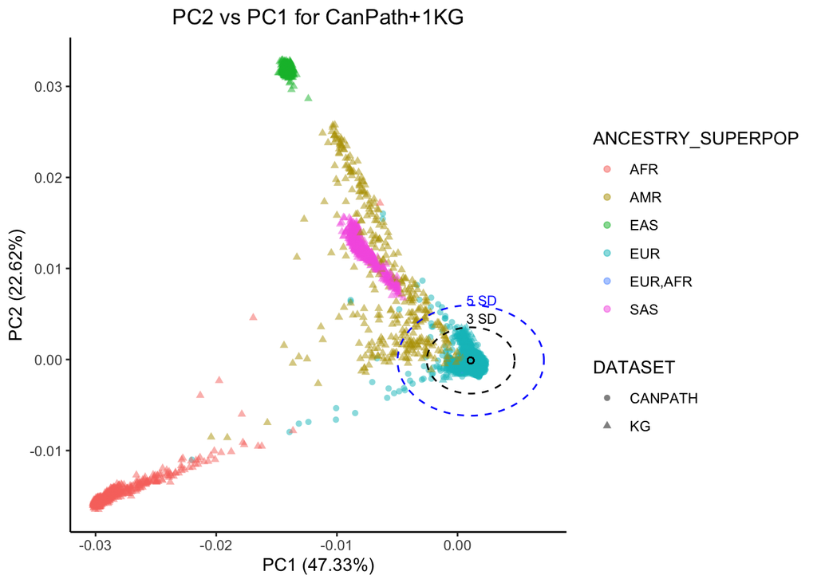

```r
# Define the radius for the circle (7SD, 10SD)
liberal_radius_factor <- 5
liberal_radius <- liberal_radius_factor * max(PCA_SD[1:2])
conservative_radius_factor <- 3
conservative_radius <- conservative_radius_factor*max(PCA_SD[1:2])

# Plot again PC2vsPC1 with circle around centroid
ggplot(PCA_PHENOTYPE_MERGED) +
  geom_point(aes(x=PC1, y=PC2, color=ANCESTRY_SUPERPOP, shape=DATASET), alpha=0.5) +
  geom_point(aes(x=PCA_MEANS[1], y=PCA_MEANS[2]), color = "black", shape=1, alpha=0.5) +
  labs(title = "PC2 vs PC1 for CanPath+1KG", x=sub("@", eval_df$var_exp_percent[1], "PC1 (@)"), y=sub("@", eval_df$var_exp_percent[2], "PC2 (@)")) +
  # 2 SD
  annotate("path", x = PCA_MEANS["PC1"] + liberal_radius * cos(seq(0, 2*pi, length.out = 100)),
           y = PCA_MEANS["PC2"] + liberal_radius * sin(seq(0, 2*pi, length.out = 100)),
           colour = "blue", linetype = "dashed") +
  # 1 SD
  annotate("path", x = PCA_MEANS["PC1"] + conservative_radius * cos(seq(0, 2*pi, length.out = 100)),
           y = PCA_MEANS["PC2"] + conservative_radius * sin(seq(0, 2*pi, length.out = 100)),
           colour = "black", linetype = "dashed") +
  annotate("text", x=0.002, y=0.0045, label="3 SD", colour="black", size=3) +
  annotate("text", x=0.002, y=0.0065, label="5 SD", colour="blue", size=3) +
  theme_classic() +
  theme(plot.title = element_text(hjust = 0.5))
```

Here we remove outliers beyond 3SD from the centroid. To briefly describe the goal, our CanPath data (all self-reported white individuals) clusters with European individuals as expected. To best control for population substructure, we now want to remove any individuals in the CanPath data who cluster away from the large European cluster (see EUR individuals in PC2vsPC1 who cluster nearer to AFR or EAS/SAS). We remove any data points whose Euclidean distance from the centroid is greater than 3x the standard deviation of the centroid.

Euclidean distance between two points can be described as (also described as Pythagorean distance for obvious reasons):

```
  D = sqrt((x2 − x1)^2 + (y2 − y1)^2)
  Euclidean distance for all points in R = sqrt(sum((xi-yi)^2))
```

```r
# Exclude all samples (both CanPath and 1KG) that fall outside of the defined radius = 3SD
is_within_radius <- function(point, centroid, radius) {
  dist <- sqrt(sum((point - centroid) ^ 2))
  return(dist <= radius)
}

PC1PC2_centroid <- c(PCA_MEANS[1], PCA_MEANS[2])

PCA_PHENOTYPE_MERGED$within_radius <- apply(PCA_PHENOTYPE_MERGED[, c("PC1", "PC2")], 1, is_within_radius, centroid = PC1PC2_centroid, radius = conservative_radius)
PCA_within_radius <- PCA_PHENOTYPE_MERGED[PCA_PHENOTYPE_MERGED$within_radius,]
PCA_new_subset <- data.frame(FID = PCA_within_radius$ID, IID = PCA_within_radius$ID)

# Create new .txt file of individuals to be kept
# 12,769 total, 12,226 CanPath
write.table(PCA_new_subset[1], file='PCA_new_subset.txt', row.names = FALSE, col.names = FALSE, quote = F)
```

can remake file in command line